# Engine Health - Data Preprocessing

```r
ds = read.csv("C:/Users/nimal/eclipse-workspace/CourseProjects/syCourseProject/DS/dataset/engine_data.csv")
```

column details

```r
summary(ds)
```

```
##    Engine.rpm     Lub.oil.pressure   Fuel.pressure       Coolant.pressure
##  Min.   :  61.0   Min.   :0.003384   Min.   : 0.003187   Min.   :0.002483
##  1st Qu.: 593.0   1st Qu.:2.518815   1st Qu.: 4.916886   1st Qu.:1.600466
##  Median : 746.0   Median :3.162035   Median : 6.201720   Median :2.166883
##  Mean   : 791.2   Mean   :3.303775   Mean   : 6.655615   Mean   :2.335369
##  3rd Qu.: 934.0   3rd Qu.:4.055272   3rd Qu.: 7.744973   3rd Qu.:2.848840
##  Max.   :2239.0   Max.   :7.265566   Max.   :21.138326   Max.   :7.478505
##   lub.oil.temp    Coolant.temp    Engine.Condition
##  Min.   :71.32   Min.   : 61.67   Min.   :0.0000
##  1st Qu.:75.73   1st Qu.: 73.90   1st Qu.:0.0000
##  Median :76.82   Median : 78.35   Median :1.0000
##  Mean   :77.64   Mean   : 78.43   Mean   :0.6305
##  3rd Qu.:78.07   3rd Qu.: 82.92   3rd Qu.:1.0000
##  Max.   :89.58   Max.   :195.53   Max.   :1.0000
```

```r
str(ds)
```

```
## 'data.frame':    19535 obs. of  7 variables:
##  $ Engine.rpm      : int  700 876 520 473 619 1221 716 729 845 824 ...
##  $ Lub.oil.pressure: num  2.49 2.94 2.96 3.71 5.67 ...
##  $ Fuel.pressure   : num  11.79 16.19 6.55 19.51 15.74 ...
##  $ Coolant.pressure: num  3.18 2.46 1.06 3.73 2.05 ...
##  $ lub.oil.temp    : num  84.1 77.6 77.8 74.1 78.4 ...
##  $ Coolant.temp    : num  81.6 82.4 79.6 71.8 87 ...
##  $ Engine.Condition: int  1 0 1 1 0 0 1 1 0 0 ...
```

### Checking For Null Values

```r
# checking for null values
sum(is.na(ds$Engine.rpm))
```

```
## [1] 0
```

```r
sum(is.na(ds$Coolant.temp))
```

```
## [1] 0
```

```r
sum(is.na(ds$lub.oil.temp))
```

```
## [1] 0
```

```r
sum(is.na(ds$Coolant.pressure))
```

```
## [1] 0
```

```r
sum(is.na(ds$Fuel.pressure))
```

```
## [1] 0
```

```r
sum(is.na(ds$Lub.oil.pressure))
```

```
## [1] 0
```

```r
sum(is.na(ds$Engine.Condition))
```

```
## [1] 0
```

## Remove Outliers

#### Engine RPM

```r
# Engine RPM analysis
data = ds$Engine.rpm
min(data)
```

```
## [1] 61
```

```r
max(data)
```

```
## [1] 2239
```

```r
mean(data)
```

```
## [1] 791.2393
```

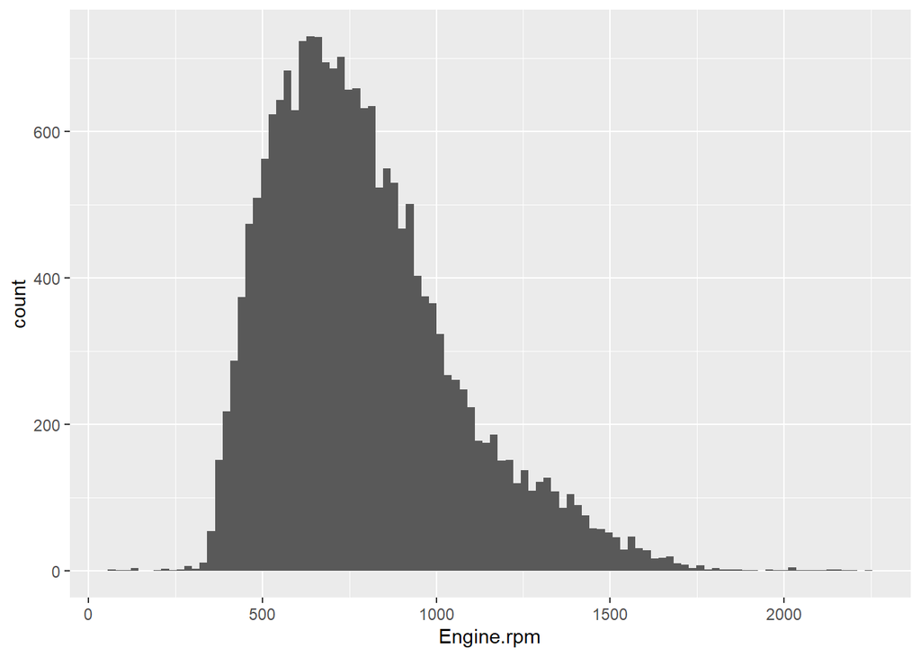

```r
library(ggplot2)
ggplot(data=ds, mapping=aes(x=Engine.rpm))+geom_histogram(bins=100)
```

```r
Q1 = quantile(ds$Engine.rpm, 0.25)
Q3 = quantile(ds$Engine.rpm, 0.75)
print(paste("25th Percentile => ", Q1))
```

```
## [1] "25th Percentile =>  593"
```

```r
print(paste("75th Percentile => ", Q3))
```

```
## [1] "75th Percentile =>  934"
```

```r
IQR = Q3 - Q1
print(paste("Inter Quartile Range => ", IQR))
```

```
## [1] "Inter Quartile Range =>  341"
```

```r
print(paste("Theoritical Min => ", Q1 - 1.7 * IQR))
```

```
## [1] "Theoritical Min =>  13.3000000000001"
```

```r
print(paste("Theoritical Max => ", Q3 + 1.7 * IQR))
```

```
## [1] "Theoritical Max =>  1513.7"
```

```r
nrow(subset(ds, ds$Engine.rpm < Q1 - 1.5 * IQR))
```

```
## [1] 2
```

```r
nrow(subset(ds, ds$Engine.rpm > Q3 + 1.5 * IQR))
```

```
## [1] 462
```

The number of outliers are small enough for us to drop them

```r
# important => do not repeat this step again and again, it will try and remove outliers from the data set who already has its outliars removed.
ds = subset(ds, ds$Engine.rpm > Q1 - 1.5 * IQR & ds$Engine.rpm < Q3 + 1.5 * IQR)
```

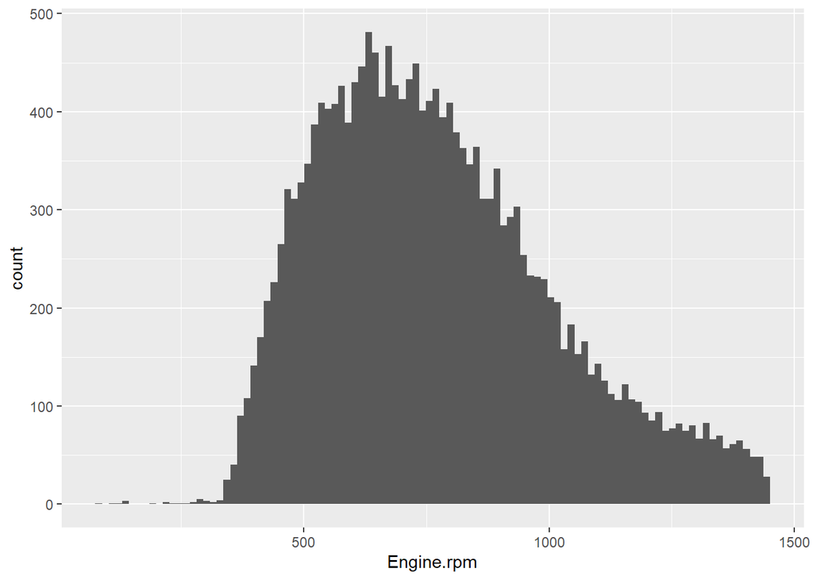

```r
ggplot(data=ds, mapping=aes(x=Engine.rpm))+geom_histogram(bins=100)
```

#### Engine Lub Oil Pressure

```r
data = ds$Lub.oil.pressure
min(data)
```

```
## [1] 0.003384113
```

```r
max(data)
```

```
## [1] 7.265566
```

```r
mean(data)
```

```
## [1] 3.302852
```

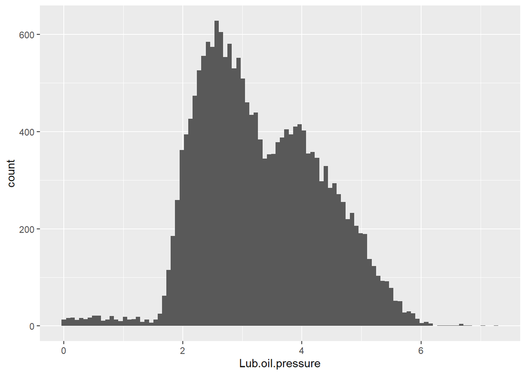

```r
ggplot(data=ds, mapping=aes(x=Lub.oil.pressure))+geom_histogram(bins=100)
```

```r
mean = mean(ds$Lub.oil.pressure)
std = sd(ds$Lub.oil.pressure)
print(mean)
```

```
## [1] 3.302852
```

```r
print(std)
```

```
## [1] 1.021967
```

```r
nrow(subset(ds, (ds$Lub.oil.pressure-mean)/std > 3.0))
```

```
## [1] 11
```

```r
nrow(subset(ds, (ds$Lub.oil.pressure-mean)/std < -3.0))
```

```
## [1] 56
```

```r
print(paste(nrow(ds), " = ", sum((ds$Lub.oil.pressure-mean)/std < -3.0 |  (ds$Lub.oil.pressure-mean)/std > 3.0), " + ", sum((ds$Lub.oil.pressure-mean)/std >= -3.0 &  (ds$Lub.oil.pressure-mean)/std <= 3.0)))
```

```
## [1] "19071  =  67  +  19004"
```

The number of outliers are small enough for us to drop them

```r
# important => do not repeat this step again and again, it will try and remove outliers from the data set who already has its outliars removed.
ds = subset(ds, (ds$Lub.oil.pressure-mean)/std >= -3.0 &  (ds$Lub.oil.pressure-mean)/std <= 3.0)
```

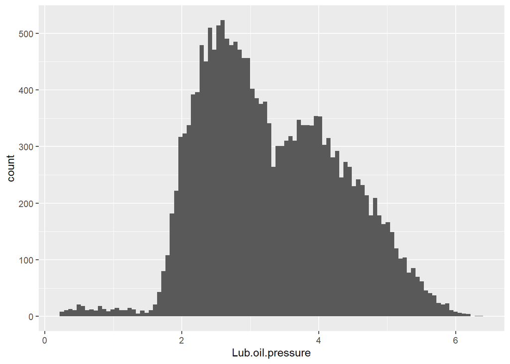

```r
ggplot(data=ds, mapping=aes(x=Lub.oil.pressure))+geom_histogram(bins=100)
```

#### Fuel.pressure

```r
data = ds$Fuel.pressure
min(data)
```

```
## [1] 0.003187131
```

```r
max(data)
```

```
## [1] 21.13833
```

```r
mean(data)
```

```
## [1] 6.655057
```

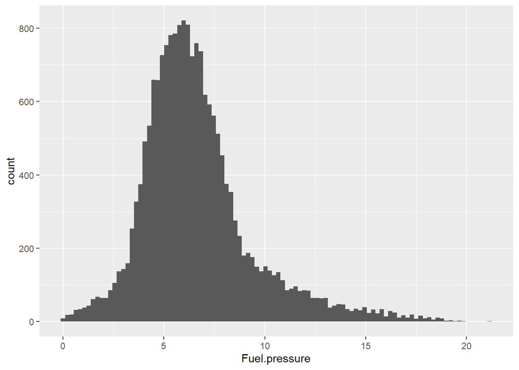

```r
ggplot(data=ds, mapping=aes(x=Fuel.pressure))+geom_histogram(bins=100)
```

```r
mean = mean(ds$Fuel.pressure)
std = sd(ds$Fuel.pressure)
print(mean)
```

```
## [1] 6.655057
```

```r
print(std)
```

```
## [1] 2.763799
```

```r
nrow(subset(ds, (ds$Fuel.pressure-mean)/std > 3.0))
```

```
## [1] 341
```

```r
nrow(subset(ds, (ds$Fuel.pressure-mean)/std < -3.0))
```

```
## [1] 0
```

```r
print(paste(nrow(ds), " = ", sum((ds$Fuel.pressure-mean)/std < -3.0 |  (ds$Fuel.pressure-mean)/std > 3.0), " + ", sum((ds$Fuel.pressure-mean)/std >= -3.0 &  (ds$Fuel.pressure-mean)/std <= 3.0)))
```

```
## [1] "19004  =  341  +  18663"
```

Hmm, just to be sure we also check out outliers by IQR method

```r
Q1 = quantile(ds$Fuel.pressure, 0.25)
Q3 = quantile(ds$Fuel.pressure, 0.75)
print(paste("25th Percentile => ", Q1))
```

```
## [1] "25th Percentile =>  4.91316581075"
```

```r
print(paste("75th Percentile => ", Q3))
```

```
## [1] "75th Percentile =>  7.74325486925"
```

```r
IQR = Q3 - Q1
print(paste("Inter Quartile Range => ", IQR))
```

```
## [1] "Inter Quartile Range =>  2.8300890585"
```

```r
print(paste("Theoritical Min => ", Q1 - 1.7 * IQR))
```

```
## [1] "Theoritical Min =>  0.102014411299999"
```

```r
print(paste("Theoritical Max => ", Q3 + 1.7 * IQR))
```

```
## [1] "Theoritical Max =>  12.5544062687"
```

```r
nrow(subset(ds, ds$Fuel.pressure < Q1 - 1.5 * IQR))
```

```
## [1] 64
```

```r
nrow(subset(ds, ds$Fuel.pressure > Q3 + 1.5 * IQR))
```

```
## [1] 1040
```

too much loss of data here as expected, so we go with our original plan, i.e. using z score

```r
# important => do not repeat this step again and again, it will try and remove outliers from the data set who already has its outliars removed.
ds = subset(ds, (ds$Fuel.pressure-mean)/std >= -3.0 &  (ds$Fuel.pressure-mean)/std <= 3.0)
```

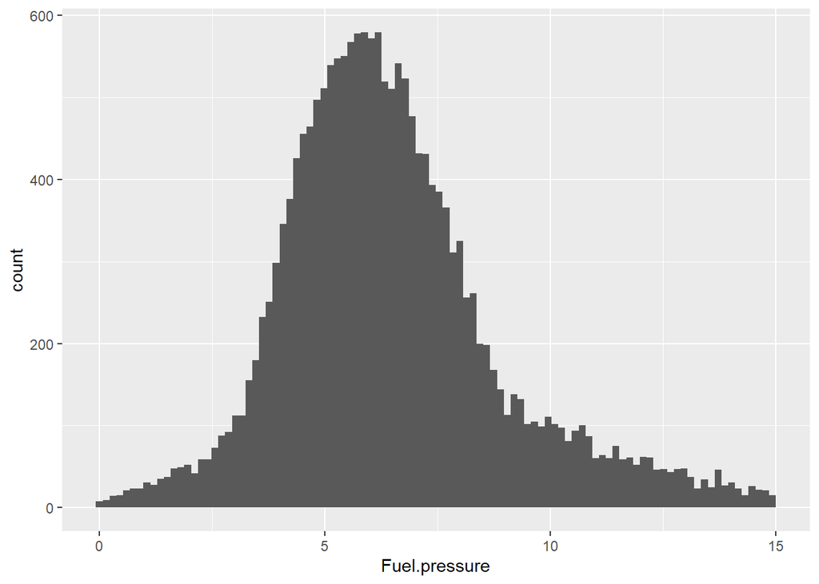

```r
ggplot(data=ds, mapping=aes(x=Fuel.pressure))+geom_histogram(bins=100)
```

#### Coolant.pressure

```r
data = ds$Coolant.pressure
min(data)
```

```
## [1] 0.002482733
```

```r
max(data)
```

```
## [1] 7.478505
```

```r
mean(data)
```

```
## [1] 2.335229
```

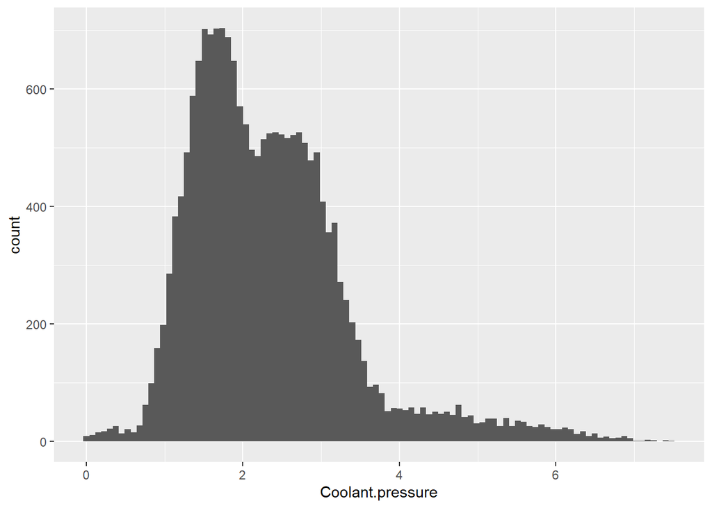

```r
ggplot(data=ds, mapping=aes(x=Coolant.pressure))+geom_histogram(bins=100)
```

```r
mean = mean(ds$Coolant.pressure)
std = sd(ds$Coolant.pressure)
print(mean)
```

```
## [1] 2.335229
```

```r
print(std)
```

```
## [1] 1.035571
```

```r
nrow(subset(ds, (ds$Coolant.pressure-mean)/std > 3.0))
```

```
## [1] 379
```

```r
nrow(subset(ds, (ds$Coolant.pressure-mean)/std < -3.0))
```

```
## [1] 0
```

```r
print(paste(nrow(ds), " = ", sum((ds$Coolant.pressure-mean)/std < -3.0 |  (ds$Coolant.pressure-mean)/std > 3.0), " + ", sum((ds$Coolant.pressure-mean)/std >= -3.0 &  (ds$Coolant.pressure-mean)/std <= 3.0)))
```

```
## [1] "18663  =  379  +  18284"
```

again, just to be sure, since graph is not perfectly normal, we check IQR method too for this

```r
Q1 = quantile(ds$Coolant.pressure, 0.25)
Q3 = quantile(ds$Coolant.pressure, 0.75)
print(paste("25th Percentile => ", Q1))
```

```
## [1] "25th Percentile =>  1.600367388"
```

```r
print(paste("75th Percentile => ", Q3))
```

```
## [1] "75th Percentile =>  2.849145497"
```

```r
IQR = Q3 - Q1
print(paste("Inter Quartile Range => ", IQR))
```

```
## [1] "Inter Quartile Range =>  1.248778109"
```

```r
print(paste("Theoritical Min => ", Q1 - 1.7 * IQR))
```

```
## [1] "Theoritical Min =>  -0.522555397300001"
```

```r
print(paste("Theoritical Max => ", Q3 + 1.7 * IQR))
```

```
## [1] "Theoritical Max =>  4.9720682823"
```

```r
nrow(subset(ds, ds$Coolant.pressure < Q1 - 1.5 * IQR))
```

```
## [1] 0
```

```r
nrow(subset(ds, ds$Coolant.pressure > Q3 + 1.5 * IQR))
```

```
## [1] 748
```

although this number is more than z score method, we still use this since it seems fair to drop these rows seeing the skeweness of graph on +ve side

```r
# important => do not repeat this step again and again, it will try and remove outliers from the data set who already has its outliars removed.
ds = subset(ds, ds$Coolant.pressure > Q1 - 1.5 * IQR & ds$Coolant.pressure < Q3 + 1.5 * IQR)
```

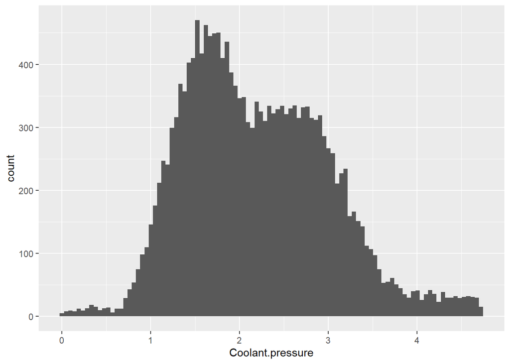

```r
ggplot(data=ds, mapping=aes(x=Coolant.pressure))+geom_histogram(bins=100)
```

#### lub.oil.temp

```r
data = ds$lub.oil.temp
min(data)
```

```
## [1] 71.32197
```

```r
max(data)
```

```
## [1] 89.5808
```

```r
mean(data)
```

```
## [1] 77.63162
```

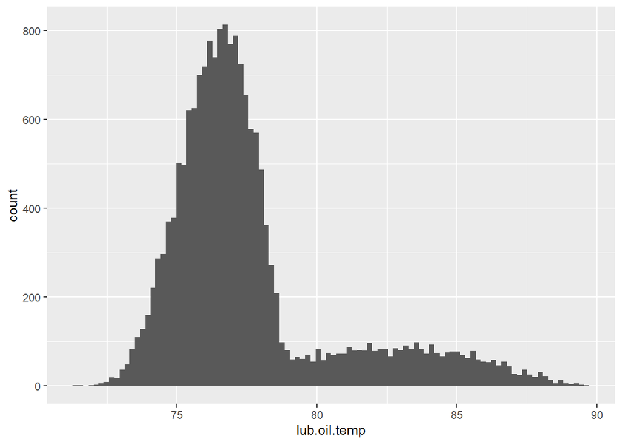

```r
ggplot(data=ds, mapping=aes(x=lub.oil.temp))+geom_histogram(bins=100)
```

# THIS IS A WIERD LOOKING GRAPH, NEED HELP TO REMOVE OUTLIERS HERE, FOR NOW WE CONTINUE WITHOUT REMOVEING OUTLIERS

#### Coolant.temp

```r
data = ds$Coolant.temp
min(data)
```

```
## [1] 61.67332
```

```r
max(data)
```

```
## [1] 195.5279
```

```r
mean(data)
```

```
## [1] 78.40126
```

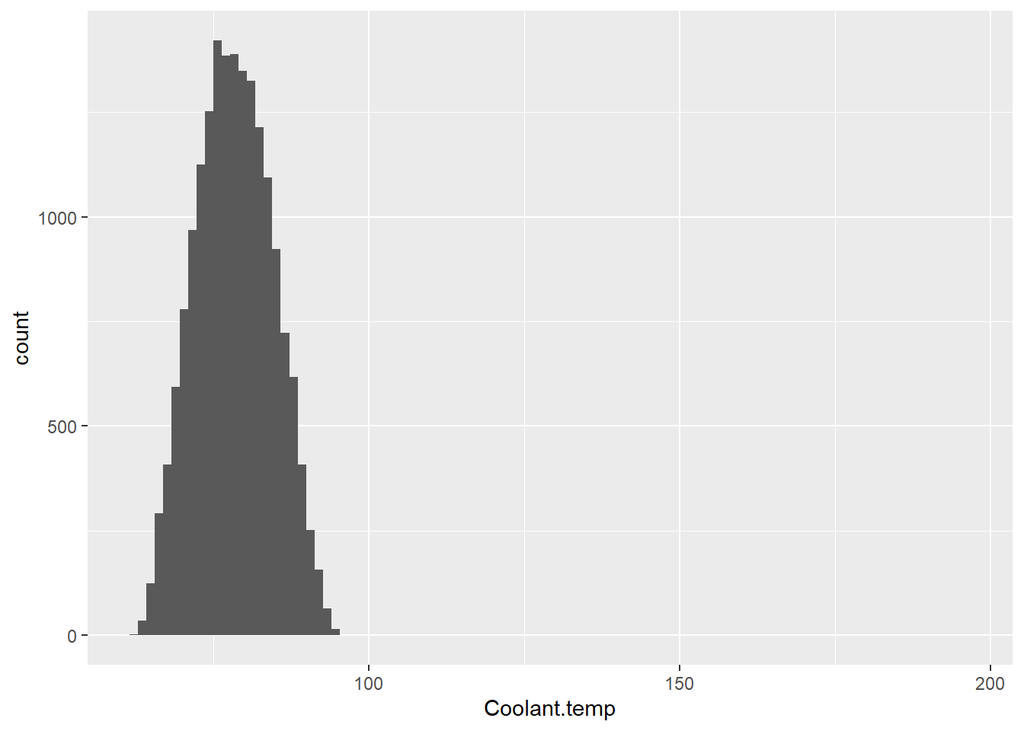

```r
ggplot(data=ds, mapping=aes(x=Coolant.temp))+geom_histogram(bins=100)
```

again, a wierd looking graph, but something seems odd here :> we will remove outlier manually if needed

```r
mean = mean(ds$Coolant.temp)
std = sd(ds$Coolant.temp)
print(mean)
```

```
## [1] 78.40126
```

```r
print(std)
```

```
## [1] 6.213893
```

```r
nrow(subset(ds, (ds$Coolant.temp-mean)/std > 3.0))
```

```
## [1] 2
```

```r
nrow(subset(ds, (ds$Coolant.temp-mean)/std < -3.0))
```

```
## [1] 0
```

```r
print(paste(nrow(ds), " = ", sum((ds$Coolant.temp-mean)/std < -3.0 |  (ds$Coolant.temp-mean)/std > 3.0), " + ", sum((ds$Coolant.temp-mean)/std >= -3.0 &  (ds$Coolant.temp-mean)/std <= 3.0)))
```

```
## [1] "17915  =  2  +  17913"
```

since outliers are obvious, we continue with the removal

```r
# important => do not repeat this step again and again, it will try and remove outliers from the data set who already has its outliars removed.
ds = subset(ds, (ds$Coolant.temp-mean)/std >= -3.0 &  (ds$Coolant.temp-mean)/std <= 3.0)
```

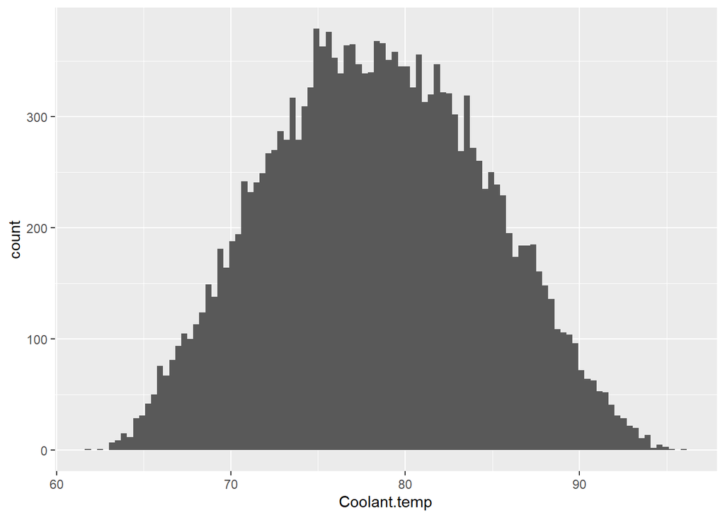

```r
ggplot(data=ds, mapping=aes(x=Coolant.temp))+geom_histogram(bins=100)
```

# Save the outliers and missing values removed File as a checkpoint

```r
write.csv(ds, "C:/Users/nimal/eclipse-workspace/CourseProjects/syCourseProject/DS/dataset/engine_data_removed_missing_and_outliers.csv", row.names=FALSE)
```

# feature scaling : now we bring all the columns scale to 0 to 1 (we use normalization since most graphs are not NORMAL, hence z score would be a poor indicator)

```r
# get the scaled one from file
ds = read.csv("C:/Users/nimal/eclipse-workspace/CourseProjects/syCourseProject/DS/dataset/engine_data_removed_missing_and_outliers.csv")
```

```r
ds$Engine.rpm = (ds$Engine.rpm - min(ds$Engine.rpm))/(max(ds$Engine.rpm) - min(ds$Engine.rpm))
ds$Lub.oil.pressure = (ds$Lub.oil.pressure - min(ds$Lub.oil.pressure))/(max(ds$Lub.oil.pressure) - min(ds$Lub.oil.pressure))
ds$Fuel.pressure = (ds$Fuel.pressure - min(ds$Fuel.pressure))/(max(ds$Fuel.pressure) - min(ds$Fuel.pressure))
ds$Coolant.pressure = (ds$Coolant.pressure - min(ds$Coolant.pressure))/(max(ds$Coolant.pressure) - min(ds$Coolant.pressure))
ds$lub.oil.temp = (ds$lub.oil.temp - min(ds$lub.oil.temp))/(max(ds$lub.oil.temp) - min(ds$lub.oil.temp))
ds$Coolant.temp = (ds$Coolant.temp - min(ds$Coolant.temp))/(max(ds$Coolant.temp) - min(ds$Coolant.temp))
```

#### test the scaled values

```r
print(paste(min(ds$Engine.rpm), max(ds$Engine.rpm)))
```

```
## [1] "0 1"
```

```r
print(paste(min(ds$Lub.oil.pressure), max(ds$Lub.oil.pressure)))
```

```
## [1] "0 1"
```

```r
print(paste(min(ds$Fuel.pressure), max(ds$Fuel.pressure)))
```

```
## [1] "0 1"
```

```r
print(paste(min(ds$Coolant.pressure), max(ds$Coolant.pressure)))
```

```
## [1] "0 1"
```

```r
print(paste(min(ds$lub.oil.temp), max(ds$lub.oil.temp)))
```

```
## [1] "0 1"
```

```r
print(paste(min(ds$Coolant.temp), max(ds$Coolant.temp)))
```

```
## [1] "0 1"
```

# Save the scaled values removed File as a checkpoint

```r
write.csv(ds, "C:/Users/nimal/eclipse-workspace/CourseProjects/syCourseProject/DS/dataset/engine_data_scaled.csv", row.names=FALSE)
```